# Parallelization in R

Ian Kloo

ian.p.kloo.civ@mail.mil

*February 2016*

This tutorial will show how to turn a regular for loop into a parallelized loop in R. This is not a computer science blog, and I am no computer scientist, but I will also show some metrics to convince you that it is worth it to parallelize your code whenever possible.

There are plenty of resources out there about this, but I found them confusing and hard to fuse together; however, if you are confused by this tutorial, there are many additional resources that are easy to find.

## What is Parallelization?

If you got this far, you probably know what parallelization is…but here we go anyway with a basic explanation:

Most modern computers have processors with more than 1 core. Think of a core as a part of your processor that can run a task. When a non-parallelized process is passed to your processor, it works as a single unit (as if it were just 1 core) to run the process and kick back the result. When a parallelized process is passed to your processor, it is divided up and run by each core, then the result is kicked back. Unsurprisingly, parallel processing is faster!

When you run R code, it is passed to your processor to execute then the result is sent back to R (this is a useful oversimplification). By default, R does not take advantage of the fact that your computer’s processor has more than 1 core.

Some R functions (like the apply() family) take advantage of parallel processing, but writing in apply() syntax can be frustrating and is not suited well for all tasks.

Thanks to some recently developed packages, you can now get R to parallelize code with relatively minimal effort. This tutorial will use the doSNOW and foreach packages, but feel free to explore the other options that are out there.

## When can I Parallelize?

Now that you understand basically what is going on when you run parallelized code, it is pretty intuitive to figure out what kind of code will benefit from parallelization: if you have many, independent tasks…parallelize!

Independent is the operative word in the above statement. Because you are splitting up your processing, you need to make sure the next computation doesn’t depend on the one before it, otherwise the parallel processing might mess up the order (actually it will just crash).

The most common type of parallelizing I have seen in R follows from a for-loop. For loops often do repeated independent tasks. The rest of this tutorial will show you how to start with a regular for-loop and parallelize it.

## The Basic For-Loop

It would be boring to use a notional for-loop, so I will use a pairwise comparison loop that has come up in a lot of my code recently.

The data we will use contains 2 dataframes of authors: 1 large table (big_table) and 1 smaller table (lookup_table). This mirrors a use case with a question like: “I have this list of people - can I see if these people appear in this other list?” Code like this is easily modified for almost anything that requires pairwise comparison.

The logic behind the code is as follows: 1. For the first name in the lookup_table dataframe: 2. Compare the name to every name in the big_table dataframe using the Jaro Winkler algorithm. 3. If a match is above a specified threshold, add it to the dataframe matches_final. 4. Repeat with all of the names in the lookup_table dataframe.

I will use the RecordLinkage package to apply the Jaro Winkler algorithm. If you are unfamiliar with Jaro Winkler, think of it as a kind of text matching that rates potential matches on a scale from 0 to 1 with 1 being an exact match.

Here is the code implementation of that loop:

```r
library(RecordLinkage)
lookup_table <- read.csv("lookup_table.csv")
big_table <- read.csv("big_table.csv")

matches.final <- data.frame('ID'= numeric(), "Name"=character(), "Affiliation"=character())
start <- Sys.time()
for (i in 1:nrow(lookup_table)){
  rpairs <- compare.linkage(lookup_table[i,],big_table, strcmp=TRUE)
  y <- rpairs$pairs[order(rpairs$pairs$Name, decreasing=TRUE),]
  y <- y[which(y$Name > .95),]

  if(nrow(y)>0){
    matches_big <- big_table[y$id2,]
    colnames(matches_big) <- c('ID.Big','Name.Big','Affiliation.Big')
    matches_lookup <- lookup_table[i,]
    colnames(matches_lookup) <- c('ID.Lookup','Name.Lookup','Affiliation.Lookup')
    matches <- cbind(matches_big,matches_lookup)
    matches.final <- rbind(matches.final, matches)
  }
  print(paste(round(i/nrow(lookup_table)*100,4)))
}
end <- Sys.time()
time <- end - start
```

This takes a little over 10 minutes to run.

When you run this code, try pressing ctrl+alt+delete and clicking “Task Manager.” In the “Performance” tab, you will see something like this:

[figure not shown]

You can see that the CPU usage is at about 30%. Also take a look at the 4 windows under “CPU Usage History.” These chart the activity of each core. You can see that 2-3 cores are fairly active, but no core is being used to its maximum. Note, this is also a good way to check how many cores you have.

## The Parallelized Loop

Now, using the exact same logic, we can create a parallelized version of the above code. I will first show the code below, then explain it. It looks intimidating at first, but is actually quite similar to the first loop.

```r
library(foreach)
library(doSNOW)
library(tcltk)

start.par <- Sys.time()
matches.final <- data.frame('ID'= numeric(), "Name"=character(), "Affiliation"=character())
ntasks <- nrow(lookup_table)
pb <- tkProgressBar(max=ntasks)
progress <- function(n) setTkProgressBar(pb, n)
opts <- list(progress=progress)
cl<-makeCluster(4, outfile='')
registerDoSNOW(cl)
matches.final <- foreach(i = 1:nrow(lookup_table), .combine = "rbind", .packages='RecordLinkage', .options.snow=opts) %dopar% {
  rpairs <- compare.linkage(lookup_table[i,],big_table, strcmp=TRUE)
  y <- rpairs$pairs[order(rpairs$pairs$Name, decreasing=TRUE),]
  y <- y[which(y$Name > .95),]

  if(nrow(y)>0){
    matches_big <- big_table[y$id2,]
    colnames(matches_big) <- c('ID.Big','Name.Big','Affiliation.Big')
    matches_lookup <- lookup_table[i,]
    colnames(matches_lookup) <- c('ID.Lookup','Name.Lookup','Affiliation.Lookup')
    matches <- cbind(matches_big,matches_lookup)
    matches.final <- rbind(matches.final, matches)
  }
}
stopCluster(cl)
end.par <- Sys.time()
time.par <- end.par - start.par
```

The first difference you will see is that we are using a few more variables before the loop. ntasks, pb, progress, and opts are all variables that are used to create a progress bar. Because we will be running a parallelized loop, we can’t just print our progress to the console like before. Now, we create a TK progress bar with the aforementioned variables and pass the option “.options.snow=opts” to the actual loop.

The next thing you will see is that we use 2 lines to ready the parallelization. makeCluster and registerDoSNOW tell the loop how many cores we want to allocate to the loop (4 in this case). I also included stopCluster(cl) at the end to shut down the parallelization.

The last difference is the beginning of the loop itself. I am using a foreach loop instead of the traditional for-loop structure. Note that foreach is just another way to write loops that are not necessarily parallelized. You can see that we pass %dopar% to the function - this is what tells R to use the clusters (cores) we opened up above. You could just pass %do% and the loop would run without parallelization.

Foreach also acts slightly different when it comes to results. This type of loop appends the result of each iteration to an object (matches.final in this case). We have to specify .combine = “rbind” in order to tell R to add the result of each iteration as new rows in a dataframe. Finally, we also have to specify .packages=“RecordLinkage” because foreach doesn’t assume any packages are loaded.

The inner workings of the function are unchanged.

This takes a little over 4 minutes to run.

While this is running, lets look at the task manager again:

[figure not shown]

As you can see, all of the cores are now at almost full capacity, as is the CPU total. We are now actually using all of our resources!

## How many Cores should I use?

The easy answer to this question is: as many as you have. You will find, however, that running all of your cores will make your computer unusable until the loop is finished. In order to show the speed gains from different configurations, check out the below chart:

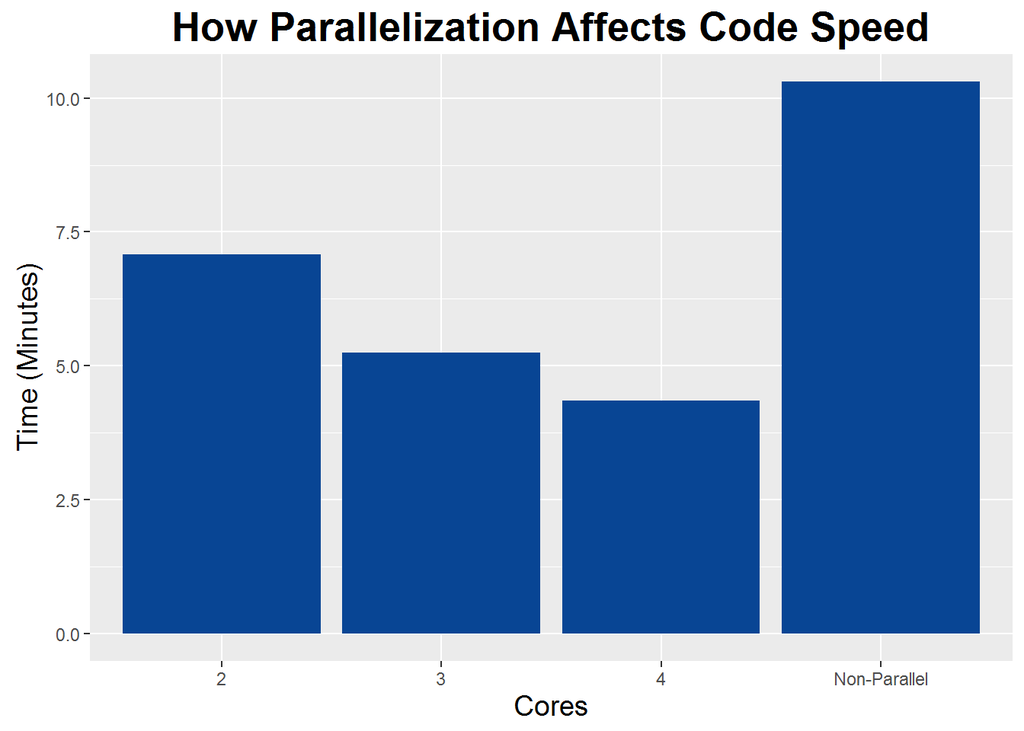

Note: changing the number of cores is as easy as changing the number in the makeCluster() function before you run the loop.

It looks like parallelizing, even to 2 cores, greatly reduces the time it takes to run this code. Unsurprisingly, using 3 and 4 cores speeds up the process even more.

This is a bit of an oversimplification: how parallelization affects your code depends on your code! However, this example shows that parallelizing can certainly be worth your time. Even if your code only takes a few minutes to run, it may be worth parallelizing if you plan to run it many times.

If you are using AWS, you may be able to leverage 8, 16, or many more cores! This would be a huge computational advantage.

## Conclusion

Hopefully you are convinced that parallelizing is a good thing, but you may be bothered by the apparent added complexity of the code. Fortunately, most of what I have above is “plug-and-play” and can be easily adapted to other pre-built loops. Give it a shot!

There is much more to know about parallelization - and I am no expert. Please feel free to correct my mistakes or start a discussion here.